# 統計的検定1

RとPython

2023-05-07

# 1 セットアップ

```r
knitr::opts_chunk$set(echo = TRUE)
library(ggplot2)
library(reticulate)
use_python("/Users/****/opt/anaconda3/envs/native/bin")
#library(lme4)
```

# 2 内容

- 平均の検定と回帰分析が同じになる例

# 3 平均の検定

- 群：2
- 対応：なし
- 正規性：あり
- 量的データ（比率データ）

### 3.1.1 データの作成

g2_rnorm_nonpaird.csvを生成する

2つの異なる平均と標準偏差を持つ正規分布から生成されたデータを含む2つのグループを作成し、それらを結合して1つのデータフレームにします。その後、ID列を追加し、結果をCSVファイルに保存します。

```r
set.seed(42)
group1 <- data.frame("g" = rep(0, 50), "F1" = rnorm(50, mean = 5, sd = 1))
group2 <- data.frame("g" = rep(1, 50), "F1" = rnorm(50, mean = 7, sd = 1))
data <- rbind(group1,group2)
data$ID <- rep(1:100, 1) # IDを追加
write.csv(data,"data/g2_rnorm_nonpaird.csv",row.names = FALSE)
```

### 3.1.2 データの読み込み

```r
data = read.csv("data/g2_rnorm_nonpaird.csv")
print(head(data))
```

```
##   g       F1 ID
## 1 0 6.370958  1
## 2 0 4.435302  2
## 3 0 5.363128  3
## 4 0 5.632863  4
## 5 0 5.404268  5
## 6 0 4.893875  6
```

### 3.1.3 基本統計量

```r
summary(data)
```

```
##        g             F1              ID
##  Min.   :0.0   Min.   :2.344   Min.   :  1.00
##  1st Qu.:0.0   1st Qu.:4.887   1st Qu.: 25.75
##  Median :0.5   Median :6.127   Median : 50.50
##  Mean   :0.5   Mean   :6.033   Mean   : 50.50
##  3rd Qu.:1.0   3rd Qu.:7.279   3rd Qu.: 75.25
##  Max.   :1.0   Max.   :8.576   Max.   :100.00
```

### 3.1.4 描画

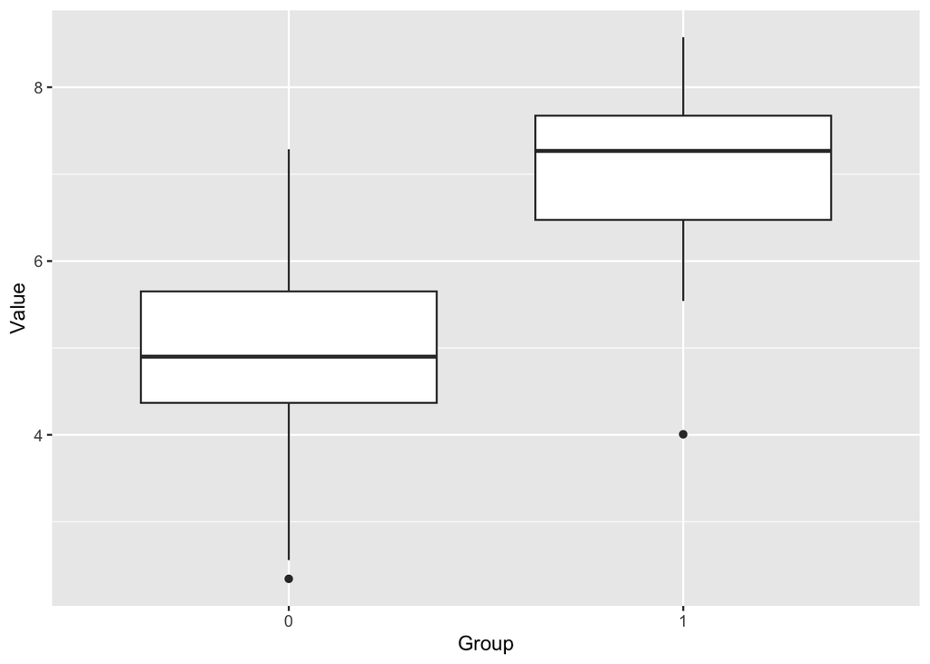

```r
ggplot(data, aes(x = as.factor(g), y = F1)) +
  geom_boxplot() +
  labs(x = "Group", y = "Value")
```

### 3.1.5 t検定の検定結果

```r
t_test <- t.test(F1 ~ g, data = data)
print(t_test)
```

```
##
##  Welch Two Sample t-test
##
## data:  F1 by g
## t = -10.228, df = 93.647, p-value < 2.2e-16
## alternative hypothesis: true difference in means between group 0 and group 1 is not equal to 0
## 95 percent confidence interval:
##  -2.551125 -1.721622
## sample estimates:
## mean in group 0 mean in group 1
##        4.964328        7.100701
```

### 3.1.6 線形回帰

```r
linear_regression <- lm(F1 ~ g, data = data)
summary(linear_regression)
```

```
##
## Call:
## lm(formula = F1 ~ g, data = data)
##
## Residuals:
##      Min       1Q   Median       3Q      Max
## -3.09379 -0.61412  0.03046  0.66774  2.32232
##
## Coefficients:
##             Estimate Std. Error t value Pr(>|t|)
## (Intercept)   4.9643     0.1477   33.61   <2e-16 ***
## g             2.1364     0.2089   10.23   <2e-16 ***
## ---
## Signif. codes:  0 '***' 0.001 '**' 0.01 '*' 0.05 '.' 0.1 ' ' 1
##
## Residual standard error: 1.044 on 98 degrees of freedom
## Multiple R-squared:  0.5163, Adjusted R-squared:  0.5114
## F-statistic: 104.6 on 1 and 98 DF,  p-value: < 2.2e-16
```

### 3.1.7 一般化線形混合モデルの作成

下記の様に記述することができるが、エラーが起きる。これは、IDに対応がないため

```r
# 一般化線形混合モデルの作成
#model <- glmer(F1 ~ g + (1|ID), data = data, family = gaussian)
# モデルの概要の表示
#summary(model)
```

# 4 Python

Pandasライブラリの read_csv() 関数を使用して、CSVファイルからデータを読み取ります。そして、SciPyライブラリの ttest_ind() 関数を使用して、両側の独立した2つの標本間でのt検定を実行します。data[‘g’] の値が0の行と1の行を、それぞれdata[data[‘g’] == 0][‘F1’]とdata[data[‘g’] == 1][‘F1’]で抽出します。

最後に、print() 関数を使用して、t検定の結果を表示します。

```python
import pandas as pd
from scipy.stats import ttest_ind

data = pd.read_csv("data/g2_rnorm_nonpaird.csv")

t_test = ttest_ind(data[data['g'] == 0]['F1'], data[data['g'] == 1]['F1'])

print(t_test)
```

```
## Ttest_indResult(statistic=-10.227874587569234, pvalue=3.877394713448746e-17)
```

## 4.1 R上でPythonの変数を利用

R MarkdownでPythonの変数をRで使う場合、以下の手順が必要です。

- Pythonの変数をreticulateパッケージでRの変数に変換する
- Rのコードチャンクで変換した変数を使う

```r
# 1. Pythonの変数をreticulateパッケージでRの変数に変換する
library(reticulate)
data <- py$data

# 2. Rのコードチャンクで変換した変数を使う
t.test(F1 ~ g, data=data)
```

```
##
##  Welch Two Sample t-test
##
## data:  F1 by g
## t = -10.228, df = 93.647, p-value < 2.2e-16
## alternative hypothesis: true difference in means between group 0 and group 1 is not equal to 0
## 95 percent confidence interval:
##  -2.551125 -1.721622
## sample estimates:
## mean in group 0 mean in group 1
##        4.964328        7.100701
```

上記のコードでは、まずPythonの変数dataをreticulateパッケージを使ってRの変数に変換しています。$演算子を使って、Pythonの変数をアクセスすることができます。

Rのコードチャンクで、変換したdataをt.test()関数に渡しています。このようにして、PythonとRのコードを組み合わせることができます。ただし、R MarkdownでPythonを使用する場合は、事前にreticulateパッケージをインストールする必要があります。

### 4.1.1 回帰分析を追加する

```r
linear_regression <- lm(F1 ~ g, data=data)
summary(linear_regression)
```

```
##
## Call:
## lm(formula = F1 ~ g, data = data)
##
## Residuals:
##      Min       1Q   Median       3Q      Max
## -3.09379 -0.61412  0.03046  0.66774  2.32232
##
## Coefficients:
##             Estimate Std. Error t value Pr(>|t|)
## (Intercept)   4.9643     0.1477   33.61   <2e-16 ***
## g             2.1364     0.2089   10.23   <2e-16 ***
## ---
## Signif. codes:  0 '***' 0.001 '**' 0.01 '*' 0.05 '.' 0.1 ' ' 1
##
## Residual standard error: 1.044 on 98 degrees of freedom
## Multiple R-squared:  0.5163, Adjusted R-squared:  0.5114
## F-statistic: 104.6 on 1 and 98 DF,  p-value: < 2.2e-16
```

Pythonの変数dataをRのデータフレームに変換しています。Rのt.test()関数でt検定を行い、回帰分析にはlm()関数を使用しています。summary()関数で回帰分析の結果を表示しています。